# vis_m6a

Crystal Shan

2026-09-14

```r
library(ggplot2)
library(dplyr)
library(tidyr)
library(readr)
library(stringr)
library(data.table)
library(tidyverse)
library(DT)
```

# Average m6A level at the union FIRE regions

Region-level table from 06_m6a_binned.py: for each union FIRE region and timepoint, n_cov = read x A/T-site events, n_mod = called m6A events, m6a = n_mod / n_cov, n_reads = distinct reads overlapping the region.

```r
input_dir <- "/project/spott/cshan/fiber-seq/macrophage_project/fire_frequency/methylation"
fire_dir  <- "/project/spott/cshan/fiber-seq/macrophage_project/fire_frequency"
plot_dir  <- file.path(input_dir, "plots")
dir.create(plot_dir, showWarnings = FALSE)

m6a_region <- fread(file.path(input_dir, "m6a_region_long.tsv.gz"))
head(m6a_region)
```

```
##     chrom start   end        region_id timepoint n_sites n_cov n_mod n_reads
##    <char> <int> <int>           <char>    <char>   <int> <int> <int>   <int>
## 1:   chr1 11261 11486 chr1:11261-11486     LPS_0      82   831    77      12
## 2:   chr1 21178 21359 chr1:21178-21359     LPS_0      75  5332  1110      72
## 3:   chr1 28997 29166 chr1:28997-29166     LPS_0      38   988   264      26
## 4:   chr1 29283 29478 chr1:29283-29478     LPS_0      42  1014   538      25
## 5:   chr1 29964 30121 chr1:29964-30121     LPS_0      76  1814   346      24
## 6:   chr1 38601 38804 chr1:38601-38804     LPS_0     114  2166   323      19
##          m6a
##        <num>
## 1: 0.0926594
## 2: 0.2081770
## 3: 0.2672060
## 4: 0.5305720
## 5: 0.1907390
## 6: 0.1491230
```

```r
# one timepoint -> color mapping shared by every plot
timepoint_levels <- c("LPS_0", "LPS_5", "LPS_10", "LPS_15")
timepoint_colors <- setNames(scales::hue_pal()(4), timepoint_levels)
m6a_region$timepoint <- factor(m6a_region$timepoint, levels = timepoint_levels)
```

# Cumulative distribution of region m6A level for each timepoint

for a given m6A level x, what fraction of FIRE-universe regions have level <= x? Left-shifted curve = overall lower m6A (less accessible) at that timepoint.

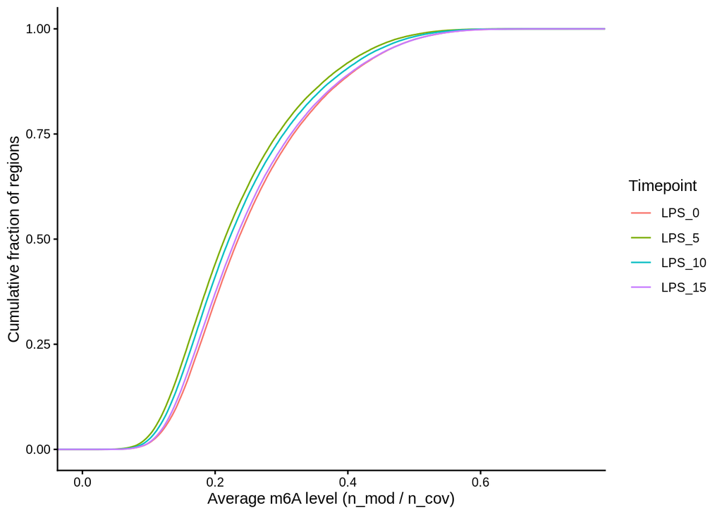

```r
p_m6a_cdf <- ggplot(m6a_region, aes(x = m6a, color = timepoint)) +
  stat_ecdf(na.rm = TRUE) +
  scale_color_manual(values = timepoint_colors) +
  labs(
    x = "Average m6A level (n_mod / n_cov)",
    y = "Cumulative fraction of regions",
    color = "Timepoint"
  ) +
  theme_classic()
p_m6a_cdf
```

```r
ggsave(file.path(plot_dir, "m6a_level_cdf.pdf"), p_m6a_cdf, width = 7, height = 4)
```

# Pairwise differential m6A level

Wilcoxon rank-sum test on per-read m6A fractions (05): reads are the independent unit, so the p-values are calibrated at read level (unlike a Fisher test on pooled read x site events, which within-read correlation inflates).

```r
pairwise_m6a <- read_tsv(file.path(input_dir, "pairwise_wilcoxon_m6a.tsv.gz"),
                         show_col_types = FALSE)

comparison_levels <- c("LPS_0_vs_LPS_5", "LPS_0_vs_LPS_10", "LPS_0_vs_LPS_15",
                       "LPS_5_vs_LPS_10", "LPS_5_vs_LPS_15", "LPS_10_vs_LPS_15")
pairwise_m6a <- pairwise_m6a %>%
  mutate(comparison = factor(comparison, levels = comparison_levels))

passing <- pairwise_m6a %>% filter(pass_coverage, !is.na(p_value))

# top 100 per comparison by raw p; head(100) instead of rank_p <= 100 because
# rank_p uses ties.method = "min" and can return != 100 rows at tie boundaries
top100 <- passing %>%
  group_by(comparison) %>%
  arrange(p_value, .by_group = TRUE) %>%
  slice_head(n = 100) %>%
  ungroup() %>%
  mutate(direction = ifelse(delta_m6a > 0, "gain", "loss"))

# gain = higher m6A level at the later timepoint
table(top100$comparison, top100$direction)
```

```
##
##                    gain loss
##   LPS_0_vs_LPS_5      1   99
##   LPS_0_vs_LPS_10    10   90
##   LPS_0_vs_LPS_15    57   43
##   LPS_5_vs_LPS_10    93    7
##   LPS_5_vs_LPS_15    99    1
##   LPS_10_vs_LPS_15   89   11
```

```r
write_tsv(top100, file.path(input_dir, "pairwise_m6a_top100.tsv"))
```

# P-value distribution per comparison

Histogram of the unadjusted Wilcoxon p-values over coverage-passing regions. The dashed red line is the count expected per bin if all p-values were uniform (no signal). An excess in the leftmost bins = real differential signal (the remaining caveat is biological: merged pools, no replication).

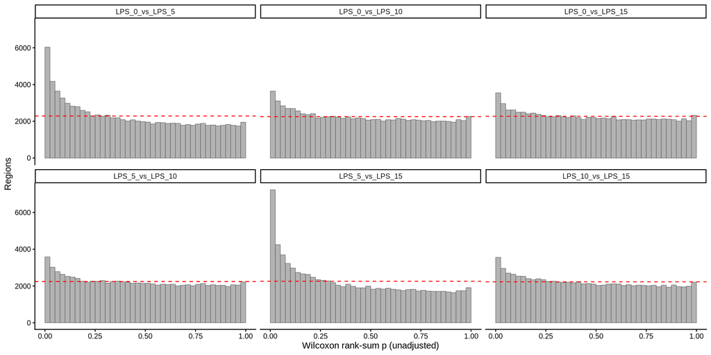

```r
expected_bin <- passing %>%
  count(comparison) %>%
  mutate(expected = n * 0.025)

p_pval_hist <- ggplot(passing, aes(x = p_value)) +
  geom_histogram(binwidth = 0.025, boundary = 0,
                 fill = "grey70", color = "grey30", linewidth = 0.2) +
  geom_hline(data = expected_bin, aes(yintercept = expected),
             linetype = "dashed", color = "red") +
  facet_wrap(~ comparison, nrow = 2) +
  labs(x = "Wilcoxon rank-sum p (unadjusted)", y = "Regions") +
  theme_classic()
p_pval_hist
```

```r
ggsave(file.path(plot_dir, "pvalue_histogram_m6a.pdf"), p_pval_hist, width = 12, height = 6)
```

# Distribution of m6A level changes

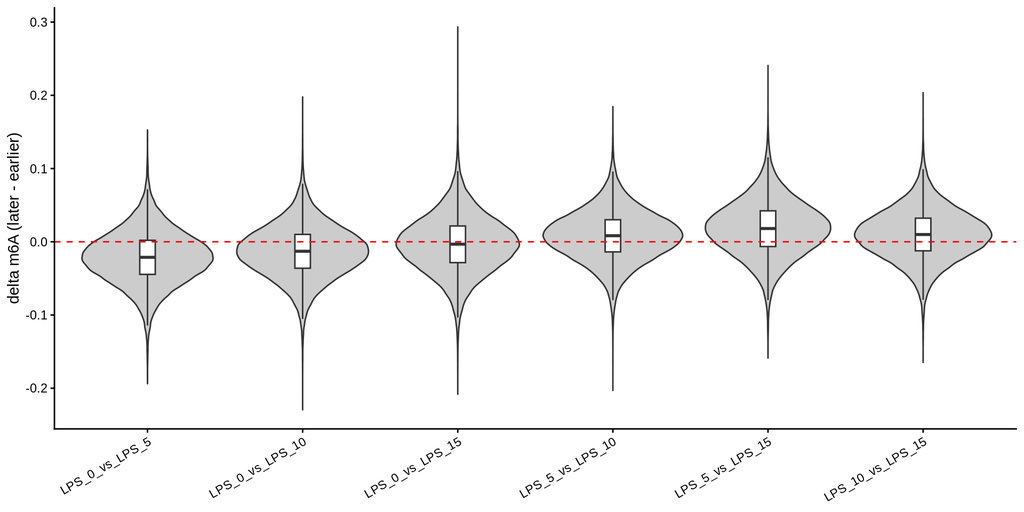

```r
p_delta_violin <- ggplot(passing, aes(x = comparison, y = delta_m6a)) +
  geom_violin(fill = "grey80") +
  geom_boxplot(width = 0.1, outlier.shape = NA) +
  geom_hline(yintercept = 0, linetype = "dashed", color = "red") +
  labs(x = NULL, y = "delta m6A (later - earlier)") +
  theme_classic() +
  theme(axis.text.x = element_text(angle = 30, hjust = 1))
p_delta_violin
```

```r
ggsave(file.path(plot_dir, "delta_m6a_violin.pdf"), p_delta_violin, width = 10, height = 5)
```

# Does m6A change where FIRE frequency changes?

Join with the FIRE-frequency Fisher results by region x comparison. FIRE elements are called from m6A density, so a positive delta_freq / delta_m6a correlation is expected by construction; the informative regions are the discordant ones.

```r
pairwise_fire <- read_tsv(file.path(fire_dir, "pairwise_fisher.tsv.gz"),
                          show_col_types = FALSE) %>%
  select(region_id, comparison, delta_freq, p_fire = p_value,
         pass_coverage_fire = pass_coverage)

both <- passing %>%
  inner_join(pairwise_fire, by = c("region_id", "comparison")) %>%
  filter(pass_coverage_fire) %>%
  mutate(fire_signif = p_fire < 0.05)

both %>%
  group_by(comparison) %>%
  summarise(spearman = cor(delta_freq, delta_m6a, method = "spearman",
                           use = "complete.obs"))
```

```
## # A tibble: 6 x 2
##   comparison       spearman
##   <chr>               <dbl>
## 1 LPS_0_vs_LPS_10     0.704
## 2 LPS_0_vs_LPS_15     0.731
## 3 LPS_0_vs_LPS_5      0.694
## 4 LPS_10_vs_LPS_15    0.707
## 5 LPS_5_vs_LPS_10     0.706
## 6 LPS_5_vs_LPS_15     0.730
```

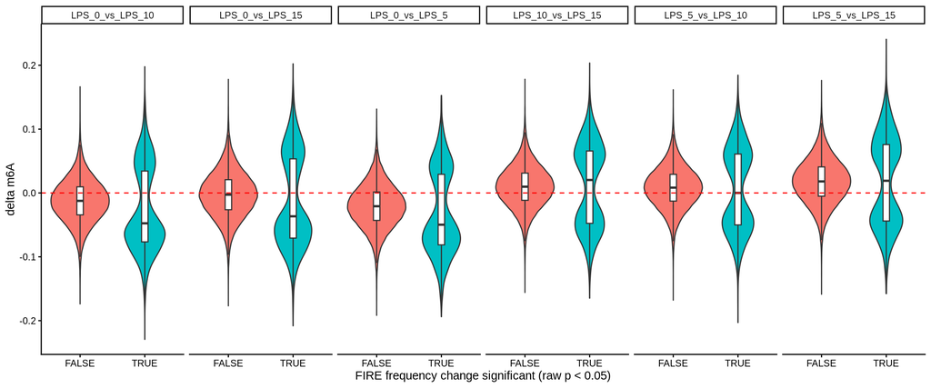

```r
# |delta_m6a| at FIRE-significant regions (raw Fisher p < 0.05 in that same
# comparison) vs the rest of the coverage-passing universe
p_sig <- ggplot(both, aes(x = fire_signif, y = delta_m6a, fill = fire_signif)) +
  geom_violin() +
  geom_boxplot(width = 0.1, outlier.shape = NA, fill = "white") +
  geom_hline(yintercept = 0, linetype = "dashed", color = "red") +
  facet_wrap(~ comparison, nrow = 1) +
  labs(x = "FIRE frequency change significant (raw p < 0.05)", y = "delta m6A") +
  theme_classic() +
  theme(legend.position = "none")
p_sig
```

```r
ggsave(file.path(plot_dir, "delta_m6a_by_fire_sig.pdf"), p_sig, width = 12, height = 5)

# regions significant in both tests (raw p < 0.05, per comparison)
both %>%
  group_by(comparison) %>%
  summarise(n_pass = n(),
            fire_sig = sum(fire_signif),
            m6a_sig = sum(p_value < 0.05),
            both_sig = sum(fire_signif & p_value < 0.05))
```

```
## # A tibble: 6 x 5
##   comparison       n_pass fire_sig m6a_sig both_sig
##   <chr>             <int>    <int>   <int>    <int>
## 1 LPS_0_vs_LPS_10   88193     4549    6609     1719
## 2 LPS_0_vs_LPS_15   89094     5571    6392     2081
## 3 LPS_0_vs_LPS_5    89690     4495   10021     1802
## 4 LPS_10_vs_LPS_15  87166     4211    6390     1474
## 5 LPS_5_vs_LPS_10   87772     4410    6445     1512
## 6 LPS_5_vs_LPS_15   88493     5722   11241     2367
```

# Read-level plots: top 5 cCRE-supported m6A changes without significant FIRE-frequency changes

Select union FIRE regions with significant methylation change (unadjusted Wilcoxon p < 0.05) but no significant FIRE-frequency change (unadjusted Fisher p >= 0.05) **in the same comparison**, passing coverage in both tests. A nonsignificant FIRE test is not evidence of equivalence; `delta_freq_best` is reported alongside the p-value. Other comparisons for a selected region may have significant FIRE-frequency changes.

As in `05_vis_fire_freq.Rmd`, require a single ENCODE cCRE to cover at least 50% of the region and the nearest GENCODE v46 gene to be protein-coding. For these examples, additionally require `gene_distance == 0` (the region overlaps or directly adjoins the gene body). Keep each region’s smallest methylation p-value among qualifying comparisons, then select the top five distinct regions overall. Here, “significant” refers to methylation change within a FIRE region, not to FIRE-frequency change.

```r
suppressPackageStartupMessages(library(GenomicRanges))
read_level_dir <- file.path(plot_dir, "read_level_results")
read_level_table_dir <- file.path(read_level_dir, "tables")
read_level_plot_dir <- file.path(read_level_dir, "plots")
dir.create(read_level_table_dir, recursive = TRUE, showWarnings = FALSE)
dir.create(read_level_plot_dir, recursive = TRUE, showWarnings = FALSE)
p_sig <- 0.05
ccre_file <- "/project/spott/cshan/annotations/GRCh38-cCREs.bed"
gtf_file <- "/project/spott/cshan/annotations/gencode.v46.annotation.gtf.gz"

m6a_only_rows <- both %>%
  filter(p_value < p_sig, !is.na(p_fire), p_fire >= p_sig)

# Choose the best qualifying comparison, with deterministic ordering for ties.
m6a_only_regions <- m6a_only_rows %>%
  group_by(region_id) %>%
  mutate(n_qualifying_comparisons = n()) %>%
  arrange(p_value, comparison, .by_group = TRUE) %>%
  slice_head(n = 1) %>%
  ungroup() %>%
  transmute(region_id, chrom, start, end, n_qualifying_comparisons,
            best_comparison = comparison, min_p = p_value,
            p_fire_best = p_fire, delta_m6a_best = delta_m6a,
            delta_freq_best = delta_freq, n_reads_A, n_reads_B)

ccre <- data.table::fread(ccre_file, header = FALSE,
                         col.names = c("chr", "start", "end",
                                       "ccre_dcc", "ccre_id", "ccre_class"))
reg.gr <- GRanges(m6a_only_regions$chrom,
                  IRanges(m6a_only_regions$start + 1L, m6a_only_regions$end))
ccre.gr <- GRanges(ccre$chr, IRanges(ccre$start + 1L, ccre$end))
hits <- findOverlaps(reg.gr, ccre.gr)
ov_frac <- width(pintersect(reg.gr[queryHits(hits)], ccre.gr[subjectHits(hits)])) /
  width(reg.gr)[queryHits(hits)]
best <- tibble(ri = queryHits(hits), frac = ov_frac,
               ccre_id = ccre$ccre_id[subjectHits(hits)],
               ccre_class = ccre$ccre_class[subjectHits(hits)]) %>%
  group_by(ri) %>%
  slice_max(frac, n = 1, with_ties = FALSE) %>%
  ungroup()

m6a_only_regions <- m6a_only_regions %>%
  mutate(ccre_frac = 0, ccre_id = NA_character_, ccre_class = NA_character_)
m6a_only_regions$ccre_frac[best$ri] <- best$frac
m6a_only_regions$ccre_id[best$ri] <- best$ccre_id
m6a_only_regions$ccre_class[best$ri] <- best$ccre_class
m6a_only_ccre <- m6a_only_regions %>% filter(ccre_frac >= 0.5)

# Annotate against all genes before filtering for a protein-coding nearest gene,
# matching the association rule in 05_vis_fire_freq.Rmd.
gtf <- data.table::fread(
  cmd = paste("zcat", shQuote(gtf_file), "| awk -F'\\t' '$3==\"gene\"'"),
  header = FALSE, sep = "\t")
genes.gr <- GRanges(gtf$V1, IRanges(gtf$V4, gtf$V5),
                    gene_name = sub('.*gene_name "([^"]+)".*', "\\1", gtf$V9),
                    gene_type = sub('.*gene_type "([^"]+)".*', "\\1", gtf$V9))
sc.gr <- GRanges(m6a_only_ccre$chrom,
                 IRanges(m6a_only_ccre$start + 1L, m6a_only_ccre$end))
d <- distanceToNearest(sc.gr, genes.gr)
m6a_only_ccre$nearest_gene <- NA_character_
m6a_only_ccre$nearest_gene_type <- NA_character_
m6a_only_ccre$gene_distance <- NA_integer_
m6a_only_ccre$nearest_gene[queryHits(d)] <- genes.gr$gene_name[subjectHits(d)]
m6a_only_ccre$nearest_gene_type[queryHits(d)] <- genes.gr$gene_type[subjectHits(d)]
m6a_only_ccre$gene_distance[queryHits(d)] <- mcols(d)$distance
m6a_only_ccre <- m6a_only_ccre %>% arrange(min_p, region_id)
write_tsv(m6a_only_ccre, file.path(read_level_table_dir, "m6a_only_ccre_regions.tsv"))

pad <- 1000L
top5_m6a_only <- m6a_only_ccre %>%
  filter(nearest_gene_type == "protein_coding", gene_distance == 0L) %>%
  slice_head(n = 5) %>%
  mutate(outname = paste(chrom, start, end, sep = "_"),
         window_start = as.integer(pmax(1L, start + 1L - pad)),
         window_end = as.integer(end + pad))
if (nrow(top5_m6a_only) < 5L) {
  warning("Only ", nrow(top5_m6a_only), " regions satisfy all selection criteria.")
}
write_tsv(top5_m6a_only, file.path(read_level_table_dir, "top5_m6a_only_ccre_regions.tsv"))

top5_m6a_only %>%
  transmute(region_id, best_comparison, n_qualifying_comparisons,
            min_p = signif(min_p, 3), p_fire_best = signif(p_fire_best, 3),
            delta_m6a_best = round(delta_m6a_best, 3),
            delta_freq_best = round(delta_freq_best, 3),
            ccre_class, ccre_frac = round(ccre_frac, 2),
            nearest_gene, gene_distance) %>%
  datatable(rownames = FALSE, options = list(pageLength = 5, scrollX = TRUE))
```

| region_id | best_comparison | n_qualifying_comparisons | min_p | p_fire_best | delta_m6a_best | delta_freq_best | ccre_class | ccre_frac | nearest_gene | gene_distance |
| --- | --- | --- | --- | --- | --- | --- | --- | --- | --- | --- |
| chr3:183382478-183382656 | LPS_5_vs_LPS_15 | 4 | 3.56e-07 | 0.279 | 0.123 | 0.102 | dELS | 1 | MCF2L2 | 0 |
| chr17:65192474-65192700 | LPS_0_vs_LPS_15 | 5 | 1.29e-06 | 0.0861 | -0.148 | -0.171 | dELS | 0.82 | RGS9 | 0 |
| chr15:100341966-100342288 | LPS_5_vs_LPS_10 | 3 | 1.31e-06 | 0.392 | 0.119 | 0.073 | PLS | 0.97 | ADAMTS17 | 0 |
| chr12:120437835-120438208 | LPS_10_vs_LPS_15 | 3 | 2.31e-06 | 0.484 | 0.096 | -0.036 | PLS | 0.91 | ENSG00000111780 | 0 |
| chr14:20609388-20609624 | LPS_0_vs_LPS_5 | 5 | 2.59e-06 | 0.168 | -0.115 | -0.143 | pELS | 1 | RNASE11 | 0 |

Plot all four timepoints with 1 kb flanks, the same panel heights, footprint colors, cCRE tracks, and highlighted tested region as the FIRE-frequency notebook. The title identifies the qualifying comparison and both p-values. Tables and PDFs are saved under `plots/read_level_results/tables` and `plots/read_level_results/plots`, respectively. Extraction is cached under `plots/read_level_results/extracted`; a completion marker is written only after the extraction script succeeds.

```r
code_dir <- "/project/spott/cshan/fiber-seq/code/topic_model/read_region_extraction"
source(file.path(code_dir, "region_data_utils.R"))
source(file.path(code_dir, "region_plot_functions.R"))
```

```r
extract_script <- file.path(code_dir, "extract_region_result_macrophage.sh")
extract_root <- file.path(read_level_dir, "extracted")
sample_names <- timepoint_levels
required_files <- c("extracted.m6a.bed.gz", "extracted.m6a.bed.gz.tbi",
                    "extracted.cpg.bed.gz", "extracted.cpg.bed.gz.tbi",
                    "region.fiberhmm_tf.bed", "region.fiberhmm_footprint.bed",
                    "fire_elements.bed", "fire.bed")

for (i in seq_len(nrow(top5_m6a_only))) {
  row <- top5_m6a_only[i, ]
  region_str <- paste0(row$chrom, ":", row$window_start, "-", row$window_end)
  for (s in sample_names) {
    parsed <- file.path(extract_root, row$outname, s, "parsed")
    marker <- file.path(parsed, "extraction_complete.txt")
    if (file.exists(marker) && identical(readLines(marker, warn = FALSE), region_str) &&
        all(file.exists(file.path(parsed, required_files))) &&
        all(file.size(file.path(parsed, required_files)) > 0) &&
        file.exists(file.path(parsed, "fire_peaks.bed"))) next
    if (file.exists(marker)) unlink(marker)
    cat("extracting", row$outname, s, "\n")
    rc <- system2("bash", shQuote(c(extract_script, s, region_str, row$outname,
                                    extract_root)))
    if (rc != 0) stop("extraction failed for ", row$outname, " ", s)
    writeLines(region_str, marker)
  }
}
```

```
## extracting chr15_100341966_100342288 LPS_0
## extracting chr15_100341966_100342288 LPS_5
## extracting chr15_100341966_100342288 LPS_10
## extracting chr15_100341966_100342288 LPS_15
## extracting chr12_120437835_120438208 LPS_0
## extracting chr12_120437835_120438208 LPS_5
## extracting chr12_120437835_120438208 LPS_10
## extracting chr12_120437835_120438208 LPS_15
## extracting chr14_20609388_20609624 LPS_0
## extracting chr14_20609388_20609624 LPS_5
## extracting chr14_20609388_20609624 LPS_10
## extracting chr14_20609388_20609624 LPS_15
```

```
## === chr3:183382478-183382656 (dELS, nearest gene: MCF2L2) ===
## Loading LPS_0 from /project/spott/cshan/fiber-seq/macrophage_project/fire_frequency/methylation/plots/read_level_results/extracted/chr3_183382478_183382656/LPS_0/parsed
## Loading LPS_5 from /project/spott/cshan/fiber-seq/macrophage_project/fire_frequency/methylation/plots/read_level_results/extracted/chr3_183382478_183382656/LPS_5/parsed
## Loading LPS_10 from /project/spott/cshan/fiber-seq/macrophage_project/fire_frequency/methylation/plots/read_level_results/extracted/chr3_183382478_183382656/LPS_10/parsed
## Loading LPS_15 from /project/spott/cshan/fiber-seq/macrophage_project/fire_frequency/methylation/plots/read_level_results/extracted/chr3_183382478_183382656/LPS_15/parsed
## 282 reads in the region across 4 samples
## 3065 TF footprints, 1023 of them inside a FIRE element
## 2243 nucleosome calls in 130-160 bp
## 282 reads in region result; 282 grouped; 0 dropped.
##
##          LPS_0 LPS_10 LPS_15 LPS_5
##   LPS_0     55      0      0     0
##   LPS_5      0      0      0    75
##   LPS_10     0     80      0     0
##   LPS_15     0      0     72     0
```

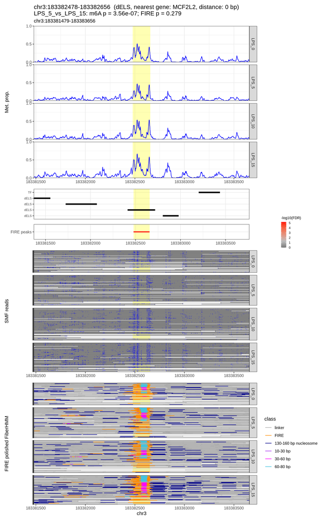

```
## === chr17:65192474-65192700 (dELS, nearest gene: RGS9) ===
## Loading LPS_0 from /project/spott/cshan/fiber-seq/macrophage_project/fire_frequency/methylation/plots/read_level_results/extracted/chr17_65192474_65192700/LPS_0/parsed
## Loading LPS_5 from /project/spott/cshan/fiber-seq/macrophage_project/fire_frequency/methylation/plots/read_level_results/extracted/chr17_65192474_65192700/LPS_5/parsed
## Loading LPS_10 from /project/spott/cshan/fiber-seq/macrophage_project/fire_frequency/methylation/plots/read_level_results/extracted/chr17_65192474_65192700/LPS_10/parsed
## Loading LPS_15 from /project/spott/cshan/fiber-seq/macrophage_project/fire_frequency/methylation/plots/read_level_results/extracted/chr17_65192474_65192700/LPS_15/parsed
## 286 reads in the region across 4 samples
## 3139 TF footprints, 647 of them inside a FIRE element
## 2468 nucleosome calls in 130-160 bp
## 286 reads in region result; 286 grouped; 0 dropped.
##
##          LPS_0 LPS_10 LPS_15 LPS_5
##   LPS_0     75      0      0     0
##   LPS_5      0      0      0    64
##   LPS_10     0     87      0     0
##   LPS_15     0      0     60     0
```

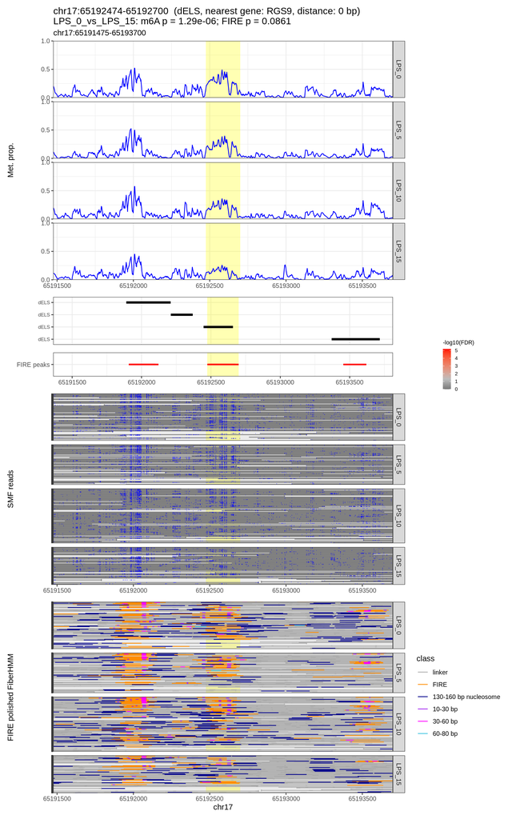

```
## === chr15:100341966-100342288 (PLS, nearest gene: ADAMTS17) ===
## Loading LPS_0 from /project/spott/cshan/fiber-seq/macrophage_project/fire_frequency/methylation/plots/read_level_results/extracted/chr15_100341966_100342288/LPS_0/parsed
## Loading LPS_5 from /project/spott/cshan/fiber-seq/macrophage_project/fire_frequency/methylation/plots/read_level_results/extracted/chr15_100341966_100342288/LPS_5/parsed
## Loading LPS_10 from /project/spott/cshan/fiber-seq/macrophage_project/fire_frequency/methylation/plots/read_level_results/extracted/chr15_100341966_100342288/LPS_10/parsed
## Loading LPS_15 from /project/spott/cshan/fiber-seq/macrophage_project/fire_frequency/methylation/plots/read_level_results/extracted/chr15_100341966_100342288/LPS_15/parsed
## 214 reads in the region across 4 samples
## 2492 TF footprints, 949 of them inside a FIRE element
## 1604 nucleosome calls in 130-160 bp
## 214 reads in region result; 214 grouped; 0 dropped.
##
##          LPS_0 LPS_10 LPS_15 LPS_5
##   LPS_0     54      0      0     0
##   LPS_5      0      0      0    52
##   LPS_10     0     63      0     0
##   LPS_15     0      0     45     0
```

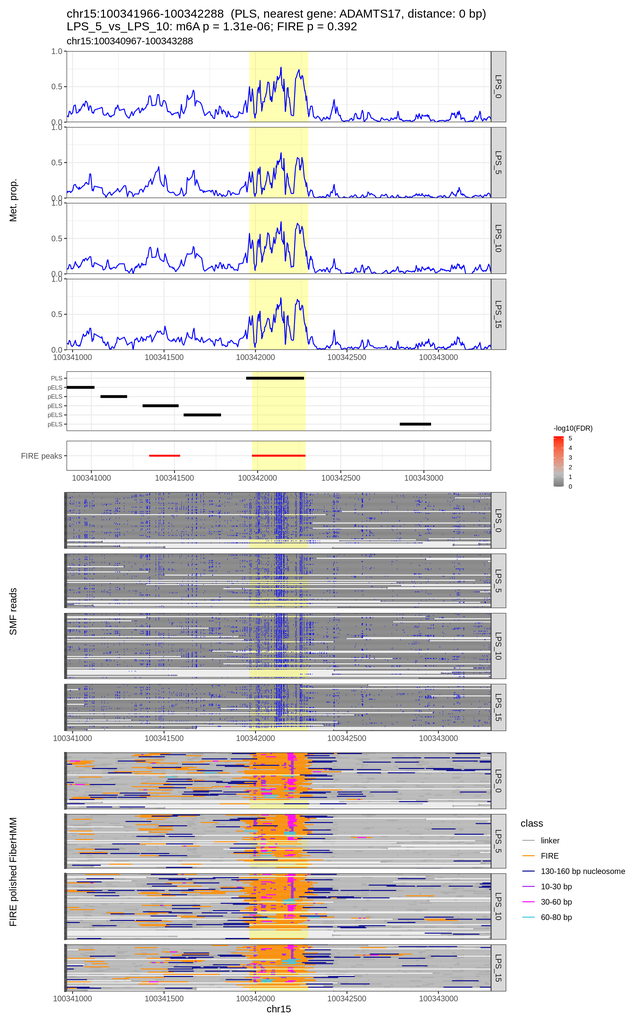

```
## === chr12:120437835-120438208 (PLS, nearest gene: ENSG00000111780) ===
## Loading LPS_0 from /project/spott/cshan/fiber-seq/macrophage_project/fire_frequency/methylation/plots/read_level_results/extracted/chr12_120437835_120438208/LPS_0/parsed
## Loading LPS_5 from /project/spott/cshan/fiber-seq/macrophage_project/fire_frequency/methylation/plots/read_level_results/extracted/chr12_120437835_120438208/LPS_5/parsed
## Loading LPS_10 from /project/spott/cshan/fiber-seq/macrophage_project/fire_frequency/methylation/plots/read_level_results/extracted/chr12_120437835_120438208/LPS_10/parsed
## Loading LPS_15 from /project/spott/cshan/fiber-seq/macrophage_project/fire_frequency/methylation/plots/read_level_results/extracted/chr12_120437835_120438208/LPS_15/parsed
## 304 reads in the region across 4 samples
## 2774 TF footprints, 848 of them inside a FIRE element
## 2134 nucleosome calls in 130-160 bp
## 304 reads in region result; 304 grouped; 0 dropped.
##
##          LPS_0 LPS_10 LPS_15 LPS_5
##   LPS_0     62      0      0     0
##   LPS_5      0      0      0    73
##   LPS_10     0     91      0     0
##   LPS_15     0      0     78     0
```

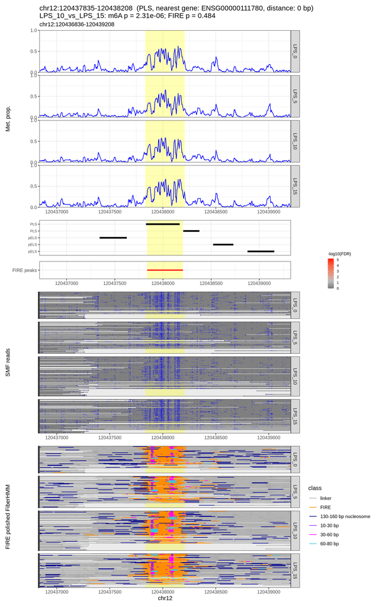

```
## === chr14:20609388-20609624 (pELS, nearest gene: RNASE11) ===
## Loading LPS_0 from /project/spott/cshan/fiber-seq/macrophage_project/fire_frequency/methylation/plots/read_level_results/extracted/chr14_20609388_20609624/LPS_0/parsed
## Loading LPS_5 from /project/spott/cshan/fiber-seq/macrophage_project/fire_frequency/methylation/plots/read_level_results/extracted/chr14_20609388_20609624/LPS_5/parsed
## Loading LPS_10 from /project/spott/cshan/fiber-seq/macrophage_project/fire_frequency/methylation/plots/read_level_results/extracted/chr14_20609388_20609624/LPS_10/parsed
## Loading LPS_15 from /project/spott/cshan/fiber-seq/macrophage_project/fire_frequency/methylation/plots/read_level_results/extracted/chr14_20609388_20609624/LPS_15/parsed
## 284 reads in the region across 4 samples
## 3768 TF footprints, 1192 of them inside a FIRE element
## 2488 nucleosome calls in 130-160 bp
## 284 reads in region result; 284 grouped; 0 dropped.
##
##          LPS_0 LPS_10 LPS_15 LPS_5
##   LPS_0     54      0      0     0
##   LPS_5      0      0      0    81
##   LPS_10     0     80      0     0
##   LPS_15     0      0     69     0
```

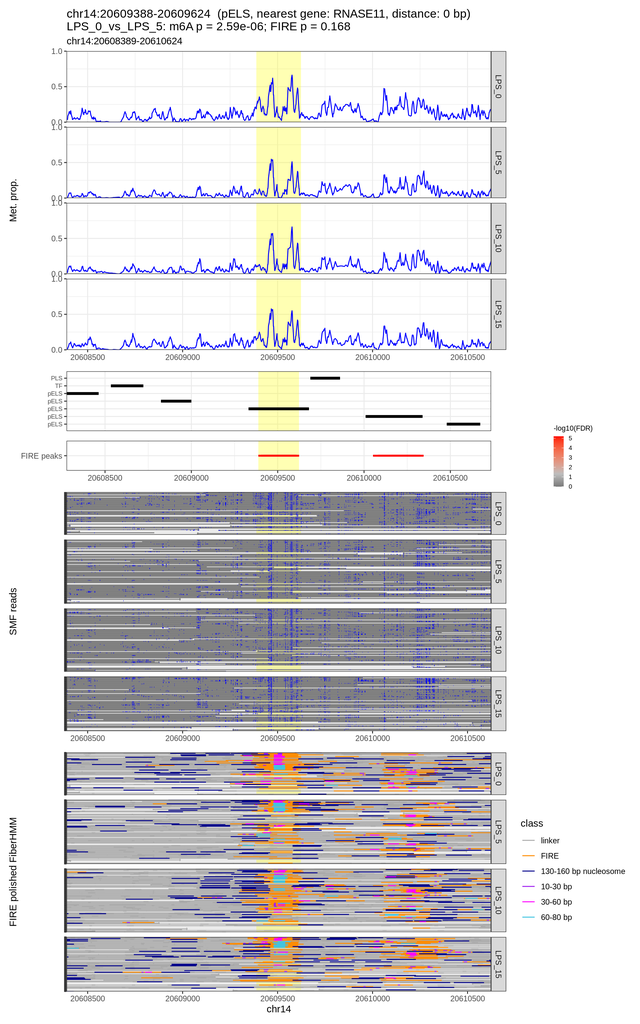

```r
for (i in seq_len(nrow(top5_m6a_only))) {
  row <- top5_m6a_only[i, ]
  cat("=== ", row$region_id, " (", row$ccre_class, ", nearest gene: ",
      row$nearest_gene, ") ===\n", sep = "")

  res <- load_region_results(
    region = data.frame(chr = row$chrom, start = row$window_start,
                        end = row$window_end),
    sample_names = sample_names,
    result_dirs = file.path(extract_root, row$outname, sample_names, "parsed"),
    fiberHMM_feature = "tf",
    min_fiberHMM_fp_score = 50,
    fiberHMM_size_breaks = c(10, 30, 60, 80))
  res <- add_read_groups(res,
                         labels = setNames(as.character(res$rids_df$sample_name),
                                           as.character(res$rids_df$RID)),
                         group_col = "timepoint",
                         group_levels = sample_names)

  peaks_df <- ccre %>%
    filter(chr == row$chrom, end > row$window_start, start < row$window_end) %>%
    arrange(ccre_class, start) %>%
    transmute(chr, start, end, group = ccre_class)
  plot_title <- paste0(
    row$region_id, "  (", row$ccre_class, ", nearest gene: ", row$nearest_gene,
    ", distance: ", row$gene_distance, " bp)\n", row$best_comparison,
    ": m6A p = ", formatC(row$min_p, format = "e", digits = 2),
    "; FIRE p = ", formatC(row$p_fire_best, format = "g", digits = 3))
  p <- plot_region_panels(res,
                          plot_name = plot_title,
                          peaks_df = peaks_df,
                          highlight = c(row$start, row$end),
                          fiberHMM_cols = c("purple", "magenta", "#41c4e1"),
                          heights = c(pileup = 10, peaks = 2, fire_peaks = 1,
                                      reads = 8, fire_fiberHMM = 8))
  print(p$combined)
  ggsave(file.path(read_level_plot_dir, paste0("m6a_only_region_", row$outname,
                                   "_by_timepoint.pdf")),
         p$combined, width = 10, height = 16, limitsize = FALSE)
}
```

# Read-level plots: top 2 cCRE-supported FIRE-frequency changes without significant m6A changes

Select regions with significant FIRE-frequency change (unadjusted Fisher p < 0.05) and no significant methylation change (unadjusted Wilcoxon p >= 0.05) **in the same comparison**, passing coverage in both tests. A nonsignificant methylation test does not establish equivalence; `delta_m6a_best` is reported alongside its p-value. Other comparisons for a selected region may have significant methylation changes.

Use the same cCRE support (at least 50% covered by one cCRE), nearest protein-coding gene, and `gene_distance == 0` requirements as above. Keep each region’s smallest FIRE p-value among qualifying comparisons, then select the top two distinct regions overall. Plot all four timepoints in the same format, saving tables and plots with a `fire_only` label in the same `read_level_results` folders.

```r
fire_only_rows <- both %>%
  filter(!is.na(p_fire), p_fire < p_sig, p_value >= p_sig)
fire_only_regions <- fire_only_rows %>%
  group_by(region_id) %>%
  mutate(n_qualifying_comparisons = n()) %>%
  arrange(p_fire, comparison, .by_group = TRUE) %>%
  slice_head(n = 1) %>%
  ungroup() %>%
  transmute(region_id, chrom, start, end, n_qualifying_comparisons,
            best_comparison = comparison, min_p = p_fire,
            p_m6a_best = p_value, delta_m6a_best = delta_m6a,
            delta_freq_best = delta_freq, n_reads_A, n_reads_B)

# Reuse the full cCRE and gene annotations loaded above, not the m6A-selected
# candidate table: the two selections have different qualifying comparisons.
fire_only.gr <- GRanges(fire_only_regions$chrom,
                        IRanges(fire_only_regions$start + 1L, fire_only_regions$end))
fire_only_hits <- findOverlaps(fire_only.gr, ccre.gr)
fire_only_frac <- width(pintersect(fire_only.gr[queryHits(fire_only_hits)],
                                  ccre.gr[subjectHits(fire_only_hits)])) /
  width(fire_only.gr)[queryHits(fire_only_hits)]
fire_only_best <- tibble(
  ri = queryHits(fire_only_hits), frac = fire_only_frac,
  ccre_id = ccre$ccre_id[subjectHits(fire_only_hits)],
  ccre_class = ccre$ccre_class[subjectHits(fire_only_hits)]) %>%
  group_by(ri) %>%
  slice_max(frac, n = 1, with_ties = FALSE) %>%
  ungroup()
fire_only_regions <- fire_only_regions %>%
  mutate(ccre_frac = 0, ccre_id = NA_character_, ccre_class = NA_character_)
fire_only_regions$ccre_frac[fire_only_best$ri] <- fire_only_best$frac
fire_only_regions$ccre_id[fire_only_best$ri] <- fire_only_best$ccre_id
fire_only_regions$ccre_class[fire_only_best$ri] <- fire_only_best$ccre_class
fire_only_ccre <- fire_only_regions %>% filter(ccre_frac >= 0.5)

fire_only_ccre.gr <- GRanges(fire_only_ccre$chrom,
                             IRanges(fire_only_ccre$start + 1L, fire_only_ccre$end))
fire_only_nearest <- distanceToNearest(fire_only_ccre.gr, genes.gr)
fire_only_ccre$nearest_gene <- NA_character_
fire_only_ccre$nearest_gene_type <- NA_character_
fire_only_ccre$gene_distance <- NA_integer_
fire_only_ccre$nearest_gene[queryHits(fire_only_nearest)] <-
  genes.gr$gene_name[subjectHits(fire_only_nearest)]
fire_only_ccre$nearest_gene_type[queryHits(fire_only_nearest)] <-
  genes.gr$gene_type[subjectHits(fire_only_nearest)]
fire_only_ccre$gene_distance[queryHits(fire_only_nearest)] <-
  mcols(fire_only_nearest)$distance
fire_only_ccre <- fire_only_ccre %>% arrange(min_p, region_id)
write_tsv(fire_only_ccre, file.path(read_level_table_dir, "fire_only_ccre_regions.tsv"))

# min_p is the FIRE-frequency Fisher p-value in this section.
top2_fire_only <- fire_only_ccre %>%
  filter(nearest_gene_type == "protein_coding", gene_distance == 0L) %>%
  slice_head(n = 2) %>%
  mutate(outname = paste(chrom, start, end, sep = "_"),
         window_start = as.integer(pmax(1L, start + 1L - pad)),
         window_end = as.integer(end + pad))
if (nrow(top2_fire_only) < 2L) {
  warning("Only ", nrow(top2_fire_only), " regions satisfy all FIRE-only selection criteria.")
}
write_tsv(top2_fire_only, file.path(read_level_table_dir, "top2_fire_only_ccre_regions.tsv"))

top2_fire_only %>%
  transmute(region_id, best_comparison, n_qualifying_comparisons,
            p_fire_best = signif(min_p, 3), p_m6a_best = signif(p_m6a_best, 3),
            delta_freq_best = round(delta_freq_best, 3),
            delta_m6a_best = round(delta_m6a_best, 3),
            ccre_class, ccre_frac = round(ccre_frac, 2),
            nearest_gene, gene_distance) %>%
  datatable(rownames = FALSE, options = list(pageLength = 2, scrollX = TRUE))
```

| region_id | best_comparison | n_qualifying_comparisons | p_fire_best | p_m6a_best | delta_freq_best | delta_m6a_best | ccre_class | ccre_frac | nearest_gene | gene_distance |
| --- | --- | --- | --- | --- | --- | --- | --- | --- | --- | --- |
| chr17:49646926-49647120 | LPS_0_vs_LPS_15 | 3 | 1.49e-05 | 0.117 | 0.351 | 0.06 | pELS | 0.88 | SPOP | 0 |
| chr15:64883161-64883451 | LPS_5_vs_LPS_15 | 3 | 2.48e-05 | 0.102 | -0.409 | -0.061 | pELS | 1 | ENSG00000249240 | 0 |

```r
extract_script <- file.path(code_dir, "extract_region_result_macrophage.sh")
extract_root <- file.path(read_level_dir, "extracted")
sample_names <- timepoint_levels
required_files <- c("extracted.m6a.bed.gz", "extracted.m6a.bed.gz.tbi",
                    "extracted.cpg.bed.gz", "extracted.cpg.bed.gz.tbi",
                    "region.fiberhmm_tf.bed", "region.fiberhmm_footprint.bed",
                    "fire_elements.bed", "fire.bed")

for (i in seq_len(nrow(top2_fire_only))) {
  row <- top2_fire_only[i, ]
  region_str <- paste0(row$chrom, ":", row$window_start, "-", row$window_end)
  for (s in sample_names) {
    parsed <- file.path(extract_root, row$outname, s, "parsed")
    marker <- file.path(parsed, "extraction_complete.txt")
    if (file.exists(marker) && identical(readLines(marker, warn = FALSE), region_str) &&
        all(file.exists(file.path(parsed, required_files))) &&
        all(file.size(file.path(parsed, required_files)) > 0) &&
        file.exists(file.path(parsed, "fire_peaks.bed"))) next
    if (file.exists(marker)) unlink(marker)
    cat("extracting", row$outname, s, "\n")
    rc <- system2("bash", shQuote(c(extract_script, s, region_str, row$outname,
                                    extract_root)))
    if (rc != 0) stop("extraction failed for ", row$outname, " ", s)
    writeLines(region_str, marker)
  }
}
```

```
## extracting chr15_64883161_64883451 LPS_0
## extracting chr15_64883161_64883451 LPS_5
## extracting chr15_64883161_64883451 LPS_10
## extracting chr15_64883161_64883451 LPS_15
```

```
## === chr17:49646926-49647120 (pELS, nearest gene: SPOP) ===
## Loading LPS_0 from /project/spott/cshan/fiber-seq/macrophage_project/fire_frequency/methylation/plots/read_level_results/extracted/chr17_49646926_49647120/LPS_0/parsed
## Loading LPS_5 from /project/spott/cshan/fiber-seq/macrophage_project/fire_frequency/methylation/plots/read_level_results/extracted/chr17_49646926_49647120/LPS_5/parsed
## Loading LPS_10 from /project/spott/cshan/fiber-seq/macrophage_project/fire_frequency/methylation/plots/read_level_results/extracted/chr17_49646926_49647120/LPS_10/parsed
## Loading LPS_15 from /project/spott/cshan/fiber-seq/macrophage_project/fire_frequency/methylation/plots/read_level_results/extracted/chr17_49646926_49647120/LPS_15/parsed
## 332 reads in the region across 4 samples
## 2916 TF footprints, 356 of them inside a FIRE element
## 2705 nucleosome calls in 130-160 bp
## 332 reads in region result; 332 grouped; 0 dropped.
##
##          LPS_0 LPS_10 LPS_15 LPS_5
##   LPS_0     82      0      0     0
##   LPS_5      0      0      0    92
##   LPS_10     0     87      0     0
##   LPS_15     0      0     71     0
```

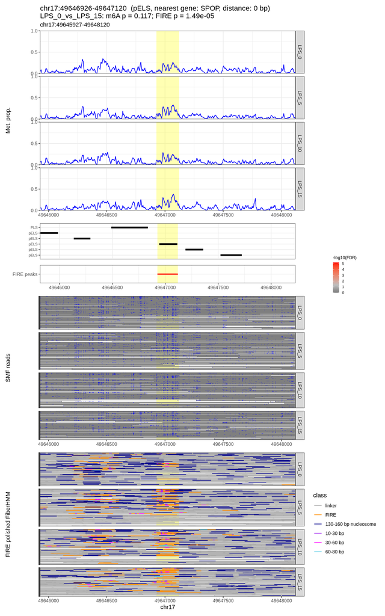

```
## === chr15:64883161-64883451 (pELS, nearest gene: ENSG00000249240) ===
## Loading LPS_0 from /project/spott/cshan/fiber-seq/macrophage_project/fire_frequency/methylation/plots/read_level_results/extracted/chr15_64883161_64883451/LPS_0/parsed
## Loading LPS_5 from /project/spott/cshan/fiber-seq/macrophage_project/fire_frequency/methylation/plots/read_level_results/extracted/chr15_64883161_64883451/LPS_5/parsed
## Loading LPS_10 from /project/spott/cshan/fiber-seq/macrophage_project/fire_frequency/methylation/plots/read_level_results/extracted/chr15_64883161_64883451/LPS_10/parsed
## Loading LPS_15 from /project/spott/cshan/fiber-seq/macrophage_project/fire_frequency/methylation/plots/read_level_results/extracted/chr15_64883161_64883451/LPS_15/parsed
## 239 reads in the region across 4 samples
## 3417 TF footprints, 1599 of them inside a FIRE element
## 1790 nucleosome calls in 130-160 bp
## 239 reads in region result; 239 grouped; 0 dropped.
##
##          LPS_0 LPS_10 LPS_15 LPS_5
##   LPS_0     57      0      0     0
##   LPS_5      0      0      0    72
##   LPS_10     0     53      0     0
##   LPS_15     0      0     57     0
```

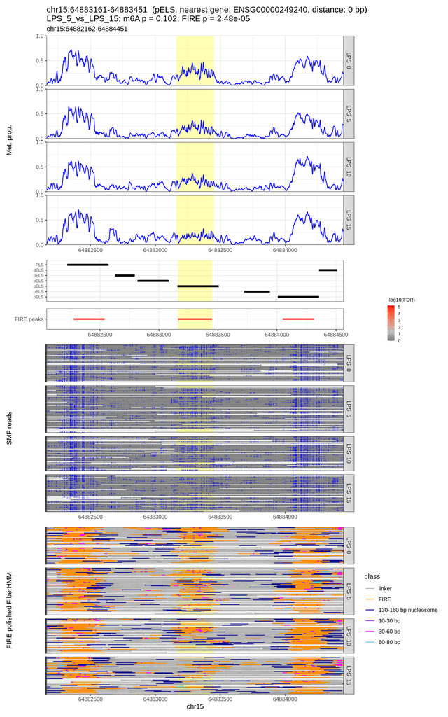

```r
for (i in seq_len(nrow(top2_fire_only))) {
  row <- top2_fire_only[i, ]
  cat("=== ", row$region_id, " (", row$ccre_class, ", nearest gene: ",
      row$nearest_gene, ") ===\n", sep = "")

  res <- load_region_results(
    region = data.frame(chr = row$chrom, start = row$window_start,
                        end = row$window_end),
    sample_names = sample_names,
    result_dirs = file.path(extract_root, row$outname, sample_names, "parsed"),
    fiberHMM_feature = "tf",
    min_fiberHMM_fp_score = 50,
    fiberHMM_size_breaks = c(10, 30, 60, 80))
  res <- add_read_groups(res,
                         labels = setNames(as.character(res$rids_df$sample_name),
                                           as.character(res$rids_df$RID)),
                         group_col = "timepoint",
                         group_levels = sample_names)

  peaks_df <- ccre %>%
    filter(chr == row$chrom, end > row$window_start, start < row$window_end) %>%
    arrange(ccre_class, start) %>%
    transmute(chr, start, end, group = ccre_class)
  plot_title <- paste0(
    row$region_id, "  (", row$ccre_class, ", nearest gene: ", row$nearest_gene,
    ", distance: ", row$gene_distance, " bp)\n", row$best_comparison,
    ": m6A p = ", formatC(row$p_m6a_best, format = "g", digits = 3),
    "; FIRE p = ", formatC(row$min_p, format = "e", digits = 2))
  p <- plot_region_panels(res,
                          plot_name = plot_title,
                          peaks_df = peaks_df,
                          highlight = c(row$start, row$end),
                          fiberHMM_cols = c("purple", "magenta", "#41c4e1"),
                          heights = c(pileup = 10, peaks = 2, fire_peaks = 1,
                                      reads = 8, fire_fiberHMM = 8))
  print(p$combined)
  ggsave(file.path(read_level_plot_dir, paste0("fire_only_region_", row$outname,
                                   "_by_timepoint.pdf")),
         p$combined, width = 10, height = 16, limitsize = FALSE)
}
```